# Netværksgraf 2

Bolette A. Jurik

10/2/2021

This version uses the functions in “graph_functions.R”.

First we load the libraries and source the functions.

```r
library(here)
library(xml2)
library(tidyverse)
library(ndjson)
library(here)
library(fs)
library(xslt)
library(tidytext)
library(ggraph)
library(igraph)
library(tidygraph)

source(here("src", "p017-functions.R"))
source(here("src", "graph_functions.R"))
source(here("src", "present_without_speech.R"))
```

Now we are ready to build the graph using the functions. Put the name of the file to use in “my_file”.

# Find speakers

```r
my_file <- "Mascarade_mod.jsonl"
(read_play_jsonl(here("test-data", my_file)) -> play)
```

```
Advarsel i stream_in_int(path.expand(path)) : Parsing error on line 230
```

| filename | act | act_number | docTitle | index | scene | scene_number | speaker | speaker_stage | spoke | stage | title | type | year |
| --- | --- | --- | --- | --- | --- | --- | --- | --- | --- | --- | --- | --- | --- |
| Mascarade_mod.jsonl | Første akt | 1 | Maskerade Komedie | 1 | Scene 1 | 1 | NA | NA | NA | Leander, Henrik | Maskerade | 1 | (1724) |
| Mascarade_mod.jsonl | Første akt | 1 | Maskerade Komedie | 2 | Scene 1 | 1 | Leander | (i sin slåbrok gnikkende sine øjne) | NA | NA | Maskerade | 3 | (1724) |
| Mascarade_mod.jsonl | Første akt | 1 | Maskerade Komedie | 3 | Scene 1 | 1 | Leander | NA | Henrik, hvad er klokken? | NA | Maskerade | 4 | (1724) |
| Mascarade_mod.jsonl | Første akt | 1 | Maskerade Komedie | 4 | Scene 1 | 1 | Henrik | (gispende) | NA | NA | Maskerade | 3 | (1724) |
| Mascarade_mod.jsonl | Første akt | 1 | Maskerade Komedie | 5 | Scene 1 | 1 | Henrik | NA | Klokken går nok til frokost, herre, men jeg ved ikke hvorfor vi skal stå så tidlig op. Se engang på uret, herre. | NA | Maskerade | 4 | (1724) |
| Mascarade_mod.jsonl | Første akt | 1 | Maskerade Komedie | 6 | Scene 1 | 1 | Leander | NA | Hillemænd! Er det muligt? Skulle vi kunne have sovet så længe, fire timer over middag? Min klokke står på fire. | NA | Maskerade | 4 | (1724) |
| Mascarade_mod.jsonl | Første akt | 1 | Maskerade Komedie | 7 | Scene 1 | 1 | Henrik | NA | Ej, det er ikke muligt, herre, det må være klokken fire om morgenen. | NA | Maskerade | 4 | (1724) |
| Mascarade_mod.jsonl | Første akt | 1 | Maskerade Komedie | 8 | Scene 1 | 1 | Leander | NA | Du skal nok se at det er så lyst klokken fire i januar måned! | NA | Maskerade | 4 | (1724) |
| Mascarade_mod.jsonl | Første akt | 1 | Maskerade Komedie | 9 | Scene 1 | 1 | Henrik | NA | Så må solen ikke gå rigtig da. Det kan jo umuligt være eftermiddag; thi nu stod vi først op. | NA | Maskerade | 4 | (1724) |
| Mascarade_mod.jsonl | Første akt | 1 | Maskerade Komedie | 10 | Scene 1 | 1 | Leander | NA | Om solen går ikke ret, så ved jeg dog at mit ur ikke løber også gal; thi det er et engelsk ur. | NA | Maskerade | 4 | (1724) |

[output cut: 800 more lines]

```r
(find_speakers(play) -> distinct_speakers)
```

| speaker | act_number | scene_number |
| --- | --- | --- |
| Leander | 1 | 1 |
| Henrik | 1 | 1 |
| Henrik | 1 | 2 |
| Arv | 1 | 2 |
| Leander | 1 | 2 |
| Magdelone | 1 | 3 |
| Leander | 1 | 3 |
| Henrik | 1 | 3 |
| Jeronimus | 1 | 4 |
| Magdelone | 1 | 4 |

[output cut: 77 more lines]

Så er der det maed at sammenlægge forskellige stavemåde af samme rolle. Det er forskelligt for hver skuespil. Det kan vi i princippet også lave funtioner for, så jeg har lavet et eksempel:

```r
(join_speakers_mascarade(distinct_speakers) -> distinct_speakers)
```

| speaker | act_number | scene_number |
| --- | --- | --- |
| Leander | 1 | 1 |
| Henrik | 1 | 1 |
| Henrik | 1 | 2 |
| Arv | 1 | 2 |
| Leander | 1 | 2 |
| Magdelone | 1 | 3 |
| Leander | 1 | 3 |
| Henrik | 1 | 3 |
| Jeronimus | 1 | 4 |
| Magdelone | 1 | 4 |

[output cut: 77 more lines]

# Find Nodes

All distinct speakers in play are the nodes.

```r
  (speakers2nodes(distinct_speakers) -> nodes)
```

| id | speaker |
| --- | --- |
| 1 | Leander |
| 2 | Henrik |
| 3 | Arv |
| 4 | Magdelone |
| 5 | Jeronimus |
| 6 | Konen |
| 7 | En karl |
| 8 | Leonard |
| 9 | Leonora |
| 10 | Pernille |

[output cut: 1 more lines]

# Find Black Edges

5. Find karakterer med replikker, der taler med hinanden – hele stykket.

```r
(find_edges(distinct_speakers) -> edges)
```

| from | to |
| --- | --- |
| Henrik | Henrik |
| Henrik | Leander |
| Leander | Henrik |
| Leander | Leander |
| Arv | Arv |
| Arv | Henrik |
| Arv | Leander |
| Henrik | Arv |
| Leander | Arv |
| Henrik | Magdelone |

[output cut: 63 more lines]

# Draw first graph

We can now draw the same graph we drew in ‘netvaerksgraf.Rmd’

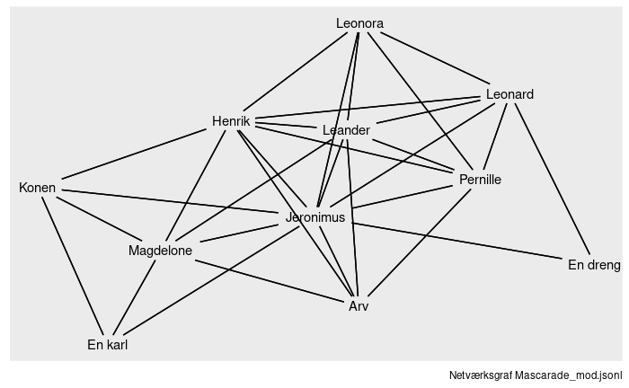

```r
gr1 <- tbl_graph(nodes = nodes, edges = edges, directed = TRUE, node_key = "speaker")

ggraph(gr1, layout = 'kk') +
    geom_edge_link(aes(start_cap = label_rect(node1.speaker),
                       end_cap = label_rect(node2.speaker))) +
      geom_node_text(aes(label = speaker)) +
    labs(caption = paste("Netværksgraf", my_file))
```